# T chimera: Mapping to the atlas

### 2.5.3 Trajectory differential expression - E7.5

```r
traj_sce = sce[, meta$trajectory.mapped %in% c("ant", "post", "nmp")]
traj_meta = meta[meta$trajectory.mapped %in% c("ant", "post", "nmp"), ]

de_t_ant = findMarkers(
  scater::normalize(traj_sce[, traj_meta$trajectory == "ant"]),
  clusters = traj_meta$tomato[traj_meta$trajectory == "ant"])

de_t_post = findMarkers(
  scater::normalize(traj_sce[, traj_meta$trajectory == "post"]),
  clusters = traj_meta$tomato[traj_meta$trajectory == "post"])

de_t_nmp = findMarkers(
  scater::normalize(traj_sce[, traj_meta$trajectory == "nmp"]),
  clusters = traj_meta$tomato[traj_meta$trajectory == "nmp"])

de_t_ant[[1]]$mgi = get_mgi(rownames(de_t_ant[[1]]))
de_t_post[[1]]$mgi = get_mgi(rownames(de_t_post[[1]]))
de_t_nmp[[1]]$mgi = get_mgi(rownames(de_t_nmp[[1]]))

write.table(de_t_ant[[1]], file = "tomato_de_anteriorsom_E7.5_t.csv",
  sep = ",", col.names = TRUE, quote = FALSE, row.names = TRUE)
write.table(de_t_post[[1]], file = "tomato_de_posteriorsom_E7.5_t.csv",
  sep = ",", col.names = TRUE, quote = FALSE, row.names = TRUE)
write.table(de_t_nmp[[1]], file = "tomato_de_nmp_E7.5_t.csv",
  sep = ",", col.names = TRUE, quote = FALSE, row.names = TRUE)
```

## 2.6 Doublet rates

The fraction of doublets in each of the 10X samples is shown in Figure 9

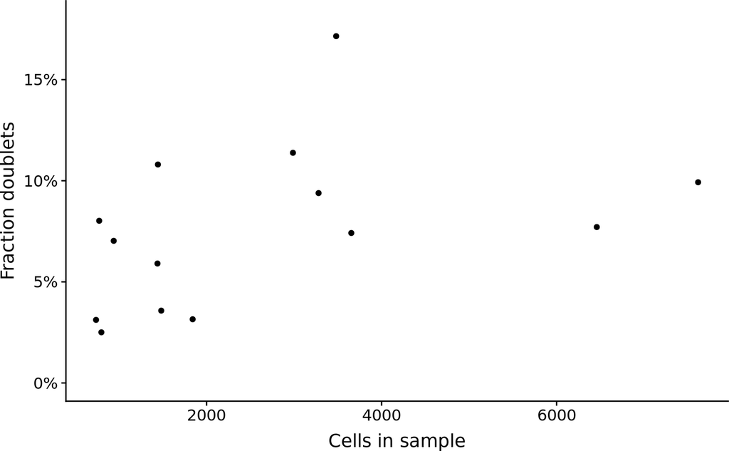

Figure 9: Number of doublets called in chimera samples

```r
pdf = data.frame(ncells = sapply(unique(meta$sample), function(x) sum(meta$sample == x)),
                 fracdoubs = sapply(unique(meta$sample), function(x) sum(meta$celltype.mapped == "Doublet" &
                                                           meta$sample == x) / sum(meta$sample == x)))

ggplot(pdf, aes(x = ncells, y= fracdoubs)) +
  geom_point() +
  scale_y_continuous(breaks = c(0,0.05,0.1, 0.15), labels = c("0%", "5%", "10%", "15%"), limits = c(0,0.18)) +
  labs(x = "Cells in sample", y = "Fraction doublets")
```

Moreover, do the cells that were mapped as doublets look like doublets? To evaluate this, we calculate the doublet density score (`scran::doubletCells`) and compare between those cells that were and were not mapped to doublets. The result is shown in Figure 10

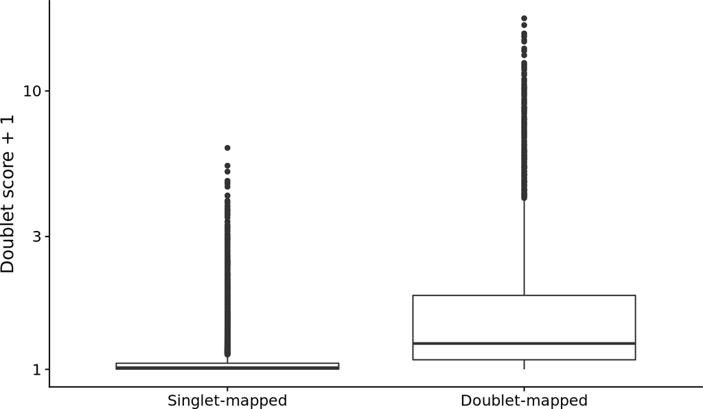

Figure 10: Doublet scores for singlet- or doublet-mapped cells

```r
scores = lapply(unique(meta$sample), function(x){
  doubletCells(scater::normalize(sce[,meta$sample == x]), approximate = TRUE)
})

scores = do.call(c, scores)

meta$doub.density = scores

ggplot(meta, aes(x = celltype.mapped == "Doublet", y = doub.density + 1)) +
  geom_boxplot() +
  scale_y_log10(name = "Doublet score + 1")+
  scale_x_discrete(labels = c("TRUE" = "Doublet-mapped", "FALSE" = "Singlet-mapped"), name = "")
```

## 2.7 Host/Injected cell frequency comparisons

Here, the fold-changes in terms of celltype frequency for each pair of samples (i.e., matched ) is shown.

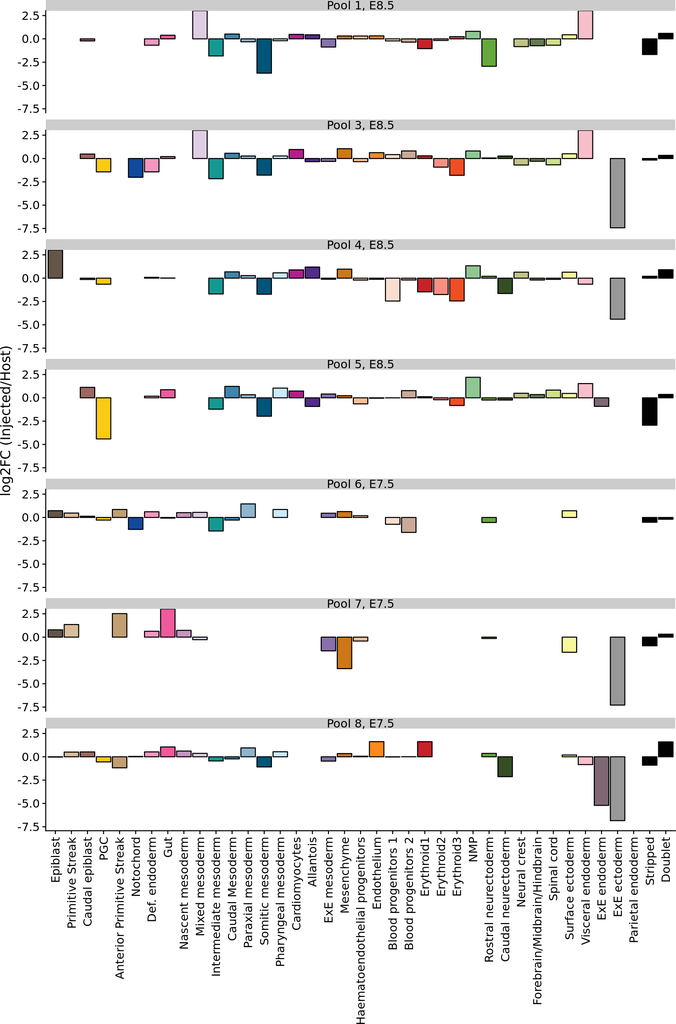

Figure 11: Relative frequencies of mapped cell type per embryo pool

```r
bigtab = sapply(unique(meta$pool), function(x){
  sub_meta = meta[meta$pool == x,]
  tab = table(factor(sub_meta$celltype.mapped, levels= unique(meta$celltype.mapped), ordered = TRUE),
              sub_meta$tomato)
  tab = sweep(tab, 2, colSums(tab), "/")
  ratio = tab[,"TRUE"]/tab[,"FALSE"]
  return(log2(ratio))
})
colnames(bigtab) = paste0("Pool ", unique(meta$pool), ", ", meta$stage[match(unique(meta$pool), meta$pool)])
mlt = melt(bigtab)
mlt$Var1 = factor(mlt$Var1, levels = c(names(celltype_colours), "Stripped", "Doublet"), ordered = TRUE)
ggplot(mlt, aes(x = Var1, y = value, fill = Var1)) +
  geom_bar(stat = "identity", col = "black") +
  scale_fill_manual(values = c(celltype_colours, "Stripped" = "black", "Doublet"= "black")) +
  facet_wrap(~Var2, ncol = 1) +
  theme(legend.position = "none") +
  theme(axis.text.x = element_text(angle = 90, hjust = 1, vjust = 0.5),
        axis.title.x = element_blank()) +
  labs(y = "log2FC (Injected/Host)")
```

# 3 Get mapped PCA with all atlas data present

```r
save(complete_atlas, complete_meta, sce, meta, file = "debug.RData")
#ensure no pool2

pca = getMappedPCA(atlas_sce = complete_atlas, atlas_meta = complete_meta, map_sce = sce[-nrow(sce),], map_meta = meta)
saveRDS(pca, file = "complete_mapped_pca.rds")


nns = queryKNN(
  X = pca[!grepl("map", rownames(pca)),],
  query = pca[grepl("map", rownames(pca)),],
  k = 1,
  get.index = TRUE)
indices = nns$index
rownames(indices) = paste0("map_", meta$cell)
umap = read.table("/nfs/research1/marioni/jonny/embryos/scripts/vis/umap/umap.tab", sep = "\t", header = FALSE)
rownames(umap) = complete_meta$cell[!(complete_meta$doublet | complete_meta$stripped)]
names(umap) = c("x", "y")
umap$colour = "none"
```

```r
ant_cells_85_tom = paste0("map_", meta$cell[which(meta$somite.subct.mapped == "Anterior-most somites" & meta$stage == "E8.5" & meta$tomato)])
ant_cells_85_tomn = paste0("map_", meta$cell[which(meta$somite.subct.mapped == "Anterior-most somites" & meta$stage == "E8.5" & !meta$tomato)])
ant_cells_75_tom = paste0("map_", meta$cell[which(meta$trajectory.mapped == "ant" & meta$stage == "E7.5" & meta$tomato)])
ant_cells_75_tomn = paste0("map_", meta$cell[which(meta$trajectory.mapped == "ant" & meta$stage == "E7.5" & !meta$tomato)])

atlas_ant_85_tom = complete_meta$cell[unique(as.numeric(indices[ant_cells_85_tom,]))]
atlas_ant_85_tomn = complete_meta$cell[unique(as.numeric(indices[ant_cells_85_tomn,]))]
atlas_ant_75_tom = complete_meta$cell[unique(as.numeric(indices[ant_cells_75_tom,]))]
atlas_ant_75_tomn = complete_meta$cell[unique(as.numeric(indices[ant_cells_75_tomn,]))]

umap$colour = sapply(rownames(umap), function(x){
  if(x %in% atlas_ant_85_tom){
    return("E8.5 Tom+")
  } else if(x %in% atlas_ant_85_tomn){
    return("E8.5 Tom-")
  } else if(x %in% atlas_ant_75_tom){
    return("E7.5 Tom+")
  } else if (x %in% atlas_ant_75_tomn){
    return("E7.5 Tom-")
  } else {return("Other")}
})
umap = umap[order(umap$colour, decreasing = TRUE),]
umap = umap[c(sample(sum(umap$colour == "Other")), sample(sum(umap$colour != "Other")) + sum(umap$colour == "Other")),]
pant = ggplot(umap) +
geom_point(mapping = aes(x = x, y=  y, col = colour), size = 0.2) +
scale_colour_manual(values = c(
  "E8.5 Tom+" = "red",
  "E8.5 Tom-" = "black",
  "E7.5 Tom+" = "pink",
  "E7.5 Tom-" = "grey40",
  "Other" = "grey90")) +
ggtitle("Anterior somites") +
theme(axis.text = element_blank(), axis.ticks = element_blank()) +
labs(x = "UMAP1", y = "UMAP2")

ggsave(pant, file = "plots/anterior_trajectory_mapped_umap.pdf", width = 6, height = 5)
```

```r
post_cells_85_tom = paste0("map_", meta$cell[which(meta$somite.subct.mapped == "Posterior-most somites" & meta$stage == "E8.5" & meta$tomato)])
post_cells_85_tomn = paste0("map_", meta$cell[which(meta$somite.subct.mapped == "Posterior-most somites" & meta$stage == "E8.5" & !meta$tomato)])
post_cells_75_tom = paste0("map_", meta$cell[which(meta$trajectory.mapped == "post" & meta$stage == "E7.5" & meta$tomato)])
post_cells_75_tomn = paste0("map_", meta$cell[which(meta$trajectory.mapped == "post" & meta$stage == "E7.5" & !meta$tomato)])

atlas_post_85_tom = complete_meta$cell[unique(as.numeric(indices[post_cells_85_tom,]))]
atlas_post_85_tomn = complete_meta$cell[unique(as.numeric(indices[post_cells_85_tomn,]))]
atlas_post_75_tom = complete_meta$cell[unique(as.numeric(indices[post_cells_75_tom,]))]
atlas_post_75_tomn = complete_meta$cell[unique(as.numeric(indices[post_cells_75_tomn,]))]

umap$colour = sapply(rownames(umap), function(x){
  if(x %in% atlas_post_85_tom){
    return("E8.5 Tom+")
  } else if(x %in% atlas_post_85_tomn){
    return("E8.5 Tom-")
  } else if(x %in% atlas_post_75_tom){
    return("E7.5 Tom+")
  } else if (x %in% atlas_post_75_tomn){
    return("E7.5 Tom-")
  } else {return("Other")}
})
umap = umap[order(umap$colour, decreasing = TRUE),]
umap = umap[c(sample(sum(umap$colour == "Other")), sample(sum(umap$colour != "Other")) + sum(umap$colour == "Other")),]
ppost = ggplot(umap) +
geom_point(mapping = aes(x = x, y=  y, col = colour), size = 0.2) +
scale_colour_manual(values = c(
  "E8.5 Tom+" = "red",
  "E8.5 Tom-" = "black",
  "E7.5 Tom+" = "pink",
  "E7.5 Tom-" = "grey40",
  "Other" = "grey90")) +
ggtitle("Posterior somites") +
theme(axis.text = element_blank(), axis.ticks = element_blank()) +
labs(x = "UMAP1", y = "UMAP2")

ggsave(ppost, file = "plots/posterior_trajectory_mapped_umap.pdf", width = 8, height = 5)
```

```r
nmp_cells_85_tom = paste0("map_", meta$cell[which(meta$celltype.mapped == "NMP" & meta$stage == "E8.5" & meta$tomato)])
nmp_cells_85_tomn = paste0("map_", meta$cell[which(meta$celltype.mapped == "NMP" & meta$stage == "E8.5" & !meta$tomato)])
nmp_cells_75_tom = paste0("map_", meta$cell[which(meta$trajectory.mapped == "nmp" & meta$stage == "E7.5" & meta$tomato)])
nmp_cells_75_tomn = paste0("map_", meta$cell[which(meta$trajectory.mapped == "nmp" & meta$stage == "E7.5" & !meta$tomato)])

atlas_nmp_85_tom = complete_meta$cell[unique(as.numeric(indices[nmp_cells_85_tom,]))]
atlas_nmp_85_tomn = complete_meta$cell[unique(as.numeric(indices[nmp_cells_85_tomn,]))]
atlas_nmp_75_tom = complete_meta$cell[unique(as.numeric(indices[nmp_cells_75_tom,]))]
atlas_nmp_75_tomn = complete_meta$cell[unique(as.numeric(indices[nmp_cells_75_tomn,]))]

umap$colour = sapply(rownames(umap), function(x){
  if(x %in% atlas_nmp_85_tom){
    return("E8.5 Tom+")
  } else if(x %in% atlas_nmp_85_tomn){
    return("E8.5 Tom-")
  } else if(x %in% atlas_nmp_75_tom){
    return("E7.5 Tom+")
  } else if (x %in% atlas_nmp_75_tomn){
    return("E7.5 Tom-")
  } else {return("Other")}
})
umap = umap[order(umap$colour, decreasing = TRUE),]
umap = umap[c(sample(sum(umap$colour == "Other")), sample(sum(umap$colour != "Other")) + sum(umap$colour == "Other")),]
pnmp = ggplot(umap) +
geom_point(mapping = aes(x = x, y=  y, col = colour), size = 0.2) +
scale_colour_manual(values = c(
  "E8.5 Tom+" = "red",
  "E8.5 Tom-" = "black",
  "E7.5 Tom+" = "pink",
  "E7.5 Tom-" = "grey40",
  "Other" = "grey90")) +
ggtitle("NMP") +
theme(axis.text = element_blank(), axis.ticks = element_blank()) +
labs(x = "UMAP1", y = "UMAP2")

ggsave(pnmp, file = "plots/NMP_trajectory_mapped_umap.pdf", width = 8, height = 5)
```

# 4 Save updated metadata

```r
#re-insert pool 2
#this inserts NAs for the doubletscore
fullmeta$doub.density = meta$doub.density[match(fullmeta$cell, meta$cell)]
fullmeta$somite.subct.mapped = meta$somite.subct.mapped[match(fullmeta$cell, meta$cell)]
fullmeta$trajectory.mapped = meta$trajectory.mapped[match(fullmeta$cell, meta$cell)]

meta = fullmeta

write.table(meta, file = "/nfs/research1/marioni/jonny/chimera-t/data/meta.tab", row.names = FALSE, col.names = TRUE, quote = FALSE, sep = "\t")
```